# maf900-a2-report

Bing HAN

2025-09-18

## Overview

We provide this report to test our two hypotheses in previous proposal as follows:  
- **H1:** Fund holdings respond positively to EPS forecasts, with heterogeneity for U.S. versus non-U.S. stocks.  
- **H2:** Cross-market heterogeneity in fund responses to EPS forecasts influences fund performance.

## I.How does cross-market EPS Forecast affect fund holdings

### A.What the data tells us

We load the integrated fund holdings + EPS forecast dataset ($fund\_hold$). After removing the influence of null values and extreme outliers, we first draw a kernel density plot of the average level of EPS quarterly differences to examine the distribution of the data.  
From the figure, we can see that the average level of quarterly differences in EPS forecast basically presents a normal distribution with a mean near 0, and the data shape is relatively good.

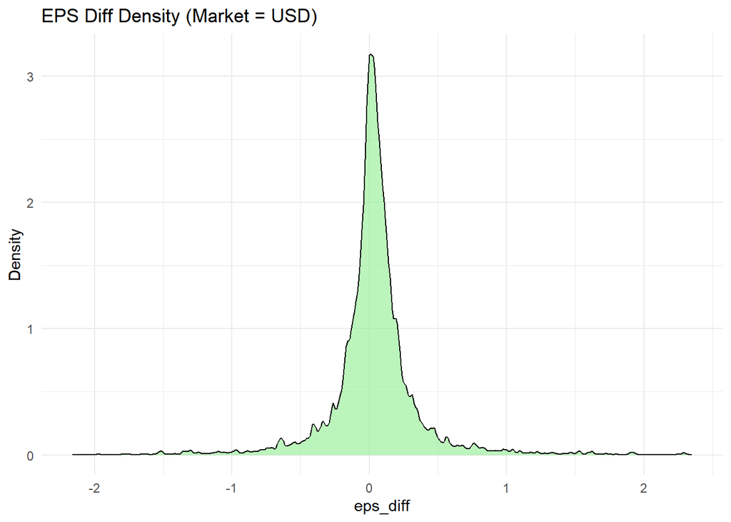

Next, we grouped the stocks by market and examined the relationship between the average level of EPS forecast quarterly difference across different markets and quarterly fund holdings changes. As the chart shows, the impact of EPS fluctuations on fund holdings in the US market is significantly greater than in other markets, and this difference does not seem to change with the magnitude of EPS forecast difference

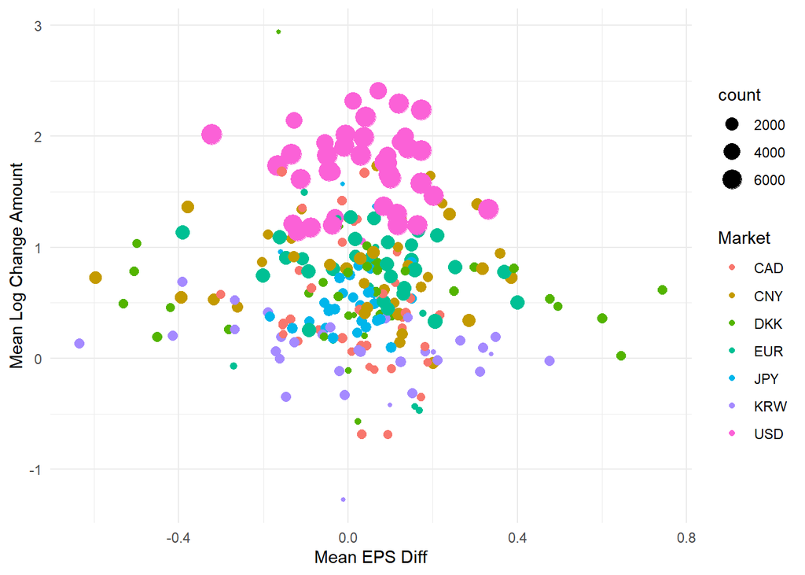

We also examined how the average level of quarterly EPS forecast difference has changed over time. The figure shows that the mean EPS forecast difference has remained relatively stable in almost all markets, with the JPY experiencing smaller fluctuations.

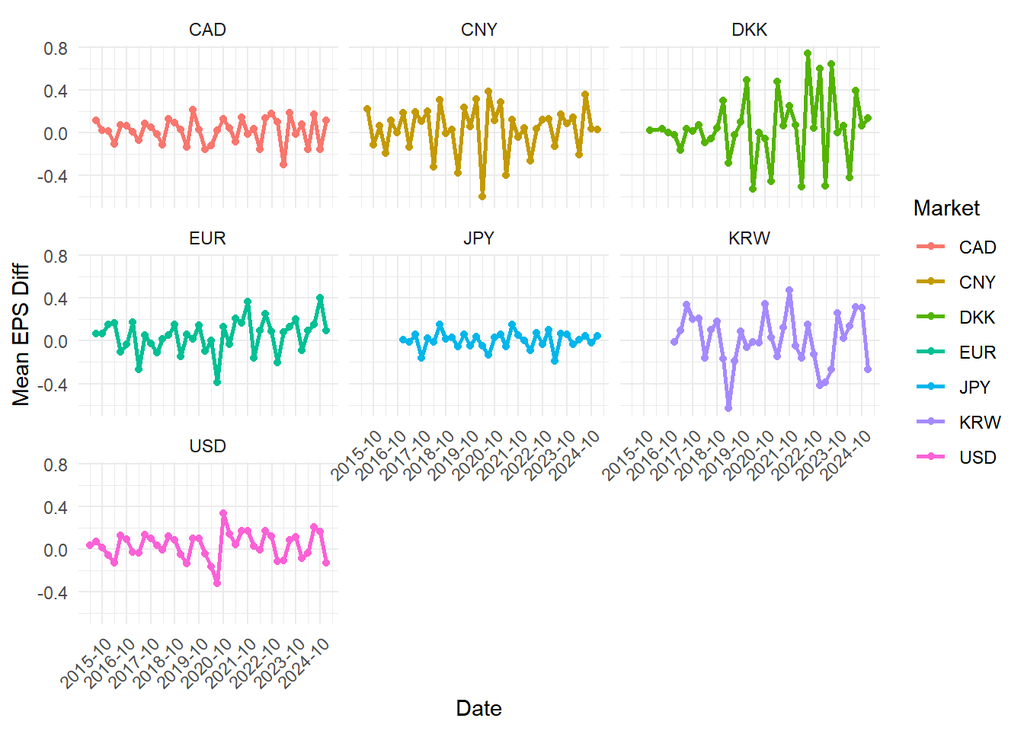

### B.Regress Holding Changes on EPS and Market

This part aims to examine how mutual fund holdings respond to analysts’ EPS forecast differences and whether such responses vary between U.S. and non-U.S. stocks (Hypothesis H1). Specifically, the models regress quarterly fund holding changes (chg_amt) on EPS forecast differences (eps_diff), a U.S. stock dummy (is_us), and their interaction, to analyze how funds adjust holdings based on EPS forecasts.

|  | All | US only | Non-US only |
| --- | --- | --- | --- |
| eps_diff | -0.06329 | 0.08301* | -0.06214 |
|  | (0.07134) | (0.04902) | (0.07220) |
| is_us | 0.90332*** |  |  |
|  | (0.05087) |  |  |
| asset | 0.39316*** | 0.48979*** | 0.31901*** |
|  | (0.04199) | (0.04674) | (0.04516) |
| eps_diff × is_us | 0.14797* |  |  |
|  | (0.08614) |  |  |
| Sample size | 464047 | 247676 | 216371 |
| Adjusted R2 | 0.14 | 0.18 | 0.08 |
| FE: Time | YES | YES | YES |
| FE: Fund | YES | YES | YES |

In Model 1 (Full Sample):

The coefficient on eps_diff is negative but insignificant, indicating that on average, fund holdings do not show a significant response to EPS forecast changes across the entire sample.

The positive and highly significant coefficient on is_us suggests that, controlling for EPS forecast differences, fund holdings in U.S. stocks are generally higher than in non-U.S. stocks, reflecting an additional effect of being a U.S. stock on holdings.

The positive and marginally significant interaction term eps_diff × is_us supports Hypothesis H1, implying that funds respond more strongly to EPS forecast changes for U.S. stocks compared to non-U.S. stocks, revealing cross-market heterogeneity.

In Model 2 (U.S. Stocks Only), the positive and marginally significant coefficient on eps_diff indicates that when analysts revise EPS forecasts upward for U.S. stocks, funds tend to increase their holdings of those stocks. This reflects a positive and sensitive response of fund holdings to EPS forecast improvements in the U.S. market.

In Model 3 (Non-U.S. Stocks Only), the coefficient on eps_diff is negative and insignificant, implying that fund holdings do not significantly increase following upward EPS forecast revisions for non-U.S. stocks. This suggests a weaker or more cautious fund response to EPS forecast changes in non-U.S. markets.

Additionally, the control variable for fund size (asset) is positive and significant across all models, indicating that larger funds tend to make larger adjustments to their holdings.

By including fund and time fixed effects, the models control for unobserved fund-specific heterogeneity and common macroeconomic shocks, ensuring that the estimated effects more accurately reflect the impact of EPS forecasts on fund holdings.

In summary, the regression results support Hypothesis H1: fund holdings exhibit significant cross-market heterogeneity in response to EPS forecasts, with stronger and positive responses in U.S. stocks and weaker responses in non-U.S. stocks. Future analysis will investigate how this heterogeneity influences fund performance (Hypothesis H2).

## II.How Cross-market heterogeneity influences fund performance

### A.Estimate Fund Abnormal Performance

To test H2, we first estimate each fund’s abnormal performance (alpha) by regressions of monthly excess returns on the Fama-French three factors and the Carhart momentum factor (Grønborg et al. 2021):
$$R_{it} = \alpha_{i} + \beta_i' Z_t +
\varepsilon_{it}$$

```
## # A tibble: 6 × 6
##   fundno     alpha beta_mkt beta_smb beta_hml  beta_umd
##    <dbl>     <dbl>    <dbl>    <dbl>    <dbl>     <dbl>
## 1      7 -0.000966    0.366  0.00483   0.0643 -0.0599
## 2      8 -0.00543     0.926  0.0311   -0.125  -0.000692
## 3      9 -0.00333     0.886 -0.161    -0.0621 -0.0967
## 4     10 -0.00170     1.01   0.118     0.326  -0.255
## 5     11 -0.00389     0.658 -0.0619   -0.0237 -0.304
## 6     13 -0.00123     0.380 -0.00427   0.0660 -0.0447
```

*Note: Due to not very long time period (2015-2024), we did not perform a rolling regression.*

### B.Regress Abnormal Performance on EPS indicators

To test Hypothesis 2 (H2), which proposes that cross-market differences in fund responses to EPS forecasts affect fund performance, we regress fund alpha on weighted EPS forecast changes for U.S. and non-U.S. stocks, along with the fund’s international holdings share. This model allows us to assess whether sensitivity to EPS revisions in different markets translates into abnormal returns, while controlling for international portfolio exposure.

|  | alpha |
| --- | --- |
| (Intercept) | -0.0017*** |
|  | (4e-04) |
| eps_diff_us | -0.0005 |
|  | (4e-04) |
| eps_diff_non_us | 0.0020*** |
|  | (3e-04) |
| intl_share | -0.0018*** |
|  | (7e-04) |
| Sample size | 4347 |
| Adjusted R2 | 0.0101 |

The second regression reveals that EPS forecast improvements for non-U.S. stocks are significantly associated with higher fund abnormal returns, while EPS improvements for U.S. stocks do not lead to significant excess returns. Additionally, a lower international holdings share is linked to better fund performance. These findings support Hypothesis 2 by demonstrating that EPS forecast improvements affect fund abnormal returns differently across U.S. and non-U.S. stocks.

## Conclusion

Funds react more strongly to EPS forecast improvements in the U.S. market by increasing holdings, but this does not translate into higher abnormal returns, likely due to stronger market efficiency and competition in the U.S. market. Conversely, EPS improvements in non-U.S. stocks are more predictive of fund performance gains. The negative relationship between international holdings and returns suggests that funds focusing less on international stocks—possibly concentrating on familiar or domestic markets—achieve better performance.